# Risk Factor Analysis

## Outcome Variable

**Outcome Variable:** co_occurence

## Predictor Variables

**Intervention Variable:** ever_wasted06

**Adjustment Set:**

- sex
- arm
- brthmon
- single
- hhwealth_quart
- W_mage
- W_mhtcm
- W_meducyrs
- W_feducyrs
- delta_brthmon
- delta_single
- delta_hhwealth_quart
- delta_W_mage
- delta_W_mhtcm
- delta_W_meducyrs
- delta_W_feducyrs

## Stratifying Variables

The analysis was stratified on these variable(s):

- studyid
- country

## Data Summary

| studyid | country | ever_wasted06 | co_occurence | n_cell | n | outcome_variable |
| --- | --- | --- | --- | --- | --- | --- |
| CMC-V-BCS-2002 | INDIA | 0 | 0 | 171 | 366 | co_occurence |
| CMC-V-BCS-2002 | INDIA | 0 | 1 | 4 | 366 | co_occurence |
| CMC-V-BCS-2002 | INDIA | 1 | 0 | 173 | 366 | co_occurence |
| CMC-V-BCS-2002 | INDIA | 1 | 1 | 18 | 366 | co_occurence |
| CMIN | BANGLADESH | 0 | 0 | 179 | 237 | co_occurence |
| CMIN | BANGLADESH | 0 | 1 | 17 | 237 | co_occurence |
| CMIN | BANGLADESH | 1 | 0 | 32 | 237 | co_occurence |
| CMIN | BANGLADESH | 1 | 1 | 9 | 237 | co_occurence |
| COHORTS | GUATEMALA | 0 | 0 | 594 | 774 | co_occurence |
| COHORTS | GUATEMALA | 0 | 1 | 26 | 774 | co_occurence |
| COHORTS | GUATEMALA | 1 | 0 | 142 | 774 | co_occurence |
| COHORTS | GUATEMALA | 1 | 1 | 12 | 774 | co_occurence |
| COHORTS | PHILIPPINES | 0 | 0 | 1777 | 2487 | co_occurence |
| COHORTS | PHILIPPINES | 0 | 1 | 112 | 2487 | co_occurence |
| COHORTS | PHILIPPINES | 1 | 0 | 523 | 2487 | co_occurence |
| COHORTS | PHILIPPINES | 1 | 1 | 75 | 2487 | co_occurence |
| CONTENT | PERU | 0 | 0 | 197 | 200 | co_occurence |
| CONTENT | PERU | 0 | 1 | 0 | 200 | co_occurence |
| CONTENT | PERU | 1 | 0 | 3 | 200 | co_occurence |
| CONTENT | PERU | 1 | 1 | 0 | 200 | co_occurence |
| EE | PAKISTAN | 0 | 0 | 190 | 346 | co_occurence |
| EE | PAKISTAN | 0 | 1 | 35 | 346 | co_occurence |
| EE | PAKISTAN | 1 | 0 | 82 | 346 | co_occurence |
| EE | PAKISTAN | 1 | 1 | 39 | 346 | co_occurence |
| GMS-Nepal | NEPAL | 0 | 0 | 302 | 550 | co_occurence |
| GMS-Nepal | NEPAL | 0 | 1 | 28 | 550 | co_occurence |
| GMS-Nepal | NEPAL | 1 | 0 | 188 | 550 | co_occurence |
| GMS-Nepal | NEPAL | 1 | 1 | 32 | 550 | co_occurence |
| IRC | INDIA | 0 | 0 | 175 | 405 | co_occurence |
| IRC | INDIA | 0 | 1 | 10 | 405 | co_occurence |

[output cut: 78 more lines]

The following strata were considered:

- studyid: CMC-V-BCS-2002, country: INDIA
- studyid: CMIN, country: BANGLADESH
- studyid: COHORTS, country: GUATEMALA
- studyid: COHORTS, country: PHILIPPINES
- studyid: CONTENT, country: PERU
- studyid: EE, country: PAKISTAN
- studyid: GMS-Nepal, country: NEPAL
- studyid: IRC, country: INDIA
- studyid: JiVitA-4, country: BANGLADESH
- studyid: Keneba, country: GAMBIA
- studyid: LCNI-5, country: MALAWI
- studyid: MAL-ED, country: BANGLADESH
- studyid: MAL-ED, country: BRAZIL
- studyid: MAL-ED, country: INDIA
- studyid: MAL-ED, country: NEPAL
- studyid: MAL-ED, country: PERU
- studyid: MAL-ED, country: SOUTH AFRICA
- studyid: MAL-ED, country: TANZANIA, UNITED REPUBLIC OF
- studyid: NIH-Birth, country: BANGLADESH
- studyid: NIH-Crypto, country: BANGLADESH
- studyid: PROBIT, country: BELARUS
- studyid: PROVIDE, country: BANGLADESH
- studyid: ResPak, country: PAKISTAN
- studyid: SAS-CompFeed, country: INDIA
- studyid: SAS-FoodSuppl, country: INDIA
- studyid: TanzaniaChild2, country: TANZANIA, UNITED REPUBLIC OF
- studyid: ZVITAMBO, country: ZIMBABWE

### Dropped Strata

Some strata were dropped due to rare outcomes:

- studyid: CMC-V-BCS-2002, country: INDIA
- studyid: CONTENT, country: PERU
- studyid: LCNI-5, country: MALAWI
- studyid: MAL-ED, country: BANGLADESH
- studyid: MAL-ED, country: BRAZIL
- studyid: MAL-ED, country: INDIA
- studyid: MAL-ED, country: NEPAL
- studyid: MAL-ED, country: PERU
- studyid: MAL-ED, country: SOUTH AFRICA
- studyid: MAL-ED, country: TANZANIA, UNITED REPUBLIC OF
- studyid: PROBIT, country: BELARUS
- studyid: ResPak, country: PAKISTAN

## Methods Detail

We’re interested in the causal parameters $E[Y_a]$ for all values of $a \in \mathcal{A}$. These parameters represent the mean outcome if, possibly contrary to fact, we intervened to set all units to have $A=a$. Under the randomization and positivity assumptions, these are identified by the statistical parameters $\psi_a=E_W[E_{Y|A,W}(Y|A=a,W)]$. In addition, we’re interested in the mean of $Y$, $E[Y]$ under no intervention (the observed mean). We will estimate these parameters by using SuperLearner to fit the relevant likelihood factors – $E_{Y|A,W}(Y|A=a,W)$ and $p(A=a|W)$, and then updating our likelihood fit using a joint TMLE.

For unadjusted analyses ($W=\{\}$), initial likelihoods were estimated using Lrnr_glm to estimate the simple $E(Y|A)$ and Lrnr_mean to estimate $p(A)$. For adjusted analyses, a small library containing Lrnr_glmnet, Lrnr_xgboost, and Lrnr_mean was used.

Having estimated these parameters, we will then use the delta method to estimate relative risks and attributable risks relative to a prespecified baseline level of $A$.

[output not shown]

[output not shown]

# Results Detail

## Results Plots

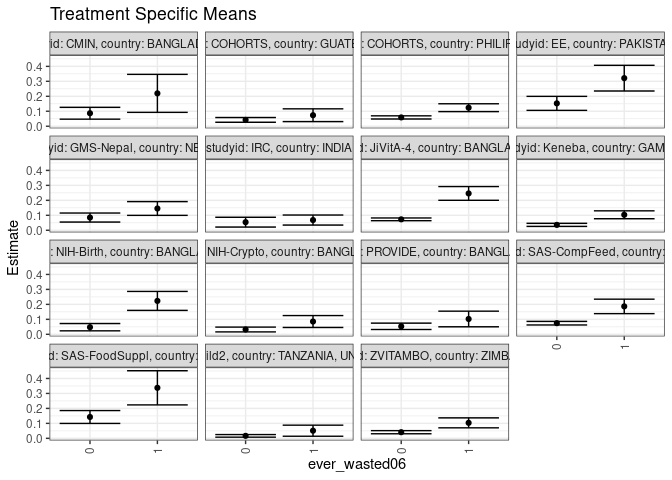

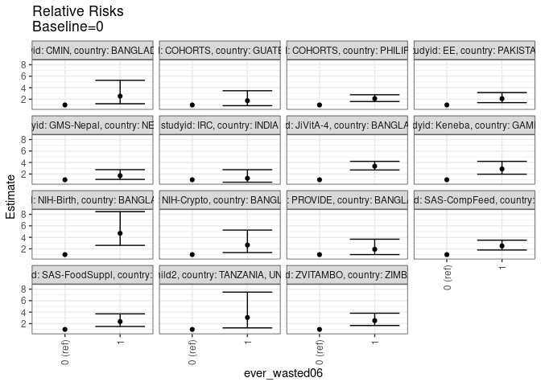

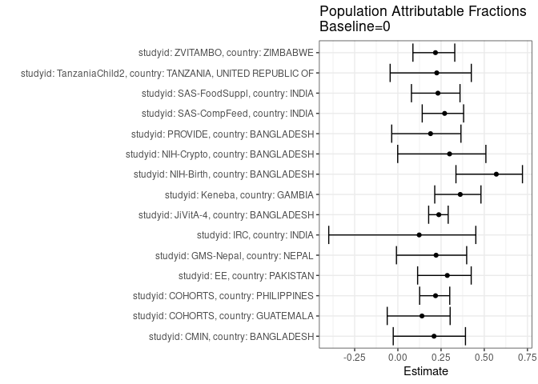

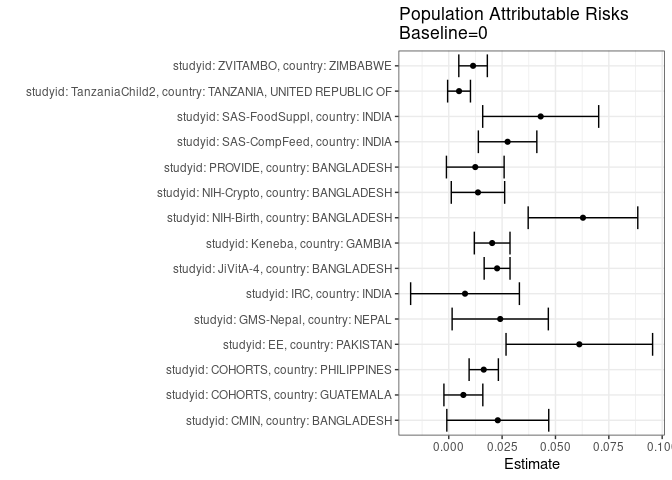

## Results Table

### Parameter: TSM

| studyid | country | intervention_level | baseline_level | estimate | ci_lower | ci_upper |
| --- | --- | --- | --- | --- | --- | --- |
| CMIN | BANGLADESH | 0 | NA | 0.0867347 | 0.0472496 | 0.1262198 |
| CMIN | BANGLADESH | 1 | NA | 0.2195122 | 0.0925464 | 0.3464780 |
| COHORTS | GUATEMALA | 0 | NA | 0.0422477 | 0.0263917 | 0.0581038 |
| COHORTS | GUATEMALA | 1 | NA | 0.0735221 | 0.0308801 | 0.1161641 |
| COHORTS | PHILIPPINES | 0 | NA | 0.0587982 | 0.0482410 | 0.0693554 |
| COHORTS | PHILIPPINES | 1 | NA | 0.1238676 | 0.0977268 | 0.1500083 |
| EE | PAKISTAN | 0 | NA | 0.1526989 | 0.1060025 | 0.1993952 |
| EE | PAKISTAN | 1 | NA | 0.3212029 | 0.2353455 | 0.4070603 |
| GMS-Nepal | NEPAL | 0 | NA | 0.0849732 | 0.0547294 | 0.1152170 |
| GMS-Nepal | NEPAL | 1 | NA | 0.1454270 | 0.0993625 | 0.1914916 |
| IRC | INDIA | 0 | NA | 0.0541103 | 0.0213724 | 0.0868481 |
| IRC | INDIA | 1 | NA | 0.0681323 | 0.0346693 | 0.1015953 |
| JiVitA-4 | BANGLADESH | 0 | NA | 0.0729983 | 0.0639392 | 0.0820574 |
| JiVitA-4 | BANGLADESH | 1 | NA | 0.2461145 | 0.2002710 | 0.2919580 |
| Keneba | GAMBIA | 0 | NA | 0.0360014 | 0.0257638 | 0.0462390 |
| Keneba | GAMBIA | 1 | NA | 0.1034418 | 0.0770520 | 0.1298315 |
| NIH-Birth | BANGLADESH | 0 | NA | 0.0475001 | 0.0230337 | 0.0719666 |
| NIH-Birth | BANGLADESH | 1 | NA | 0.2230795 | 0.1596845 | 0.2864745 |
| NIH-Crypto | BANGLADESH | 0 | NA | 0.0320541 | 0.0160593 | 0.0480489 |
| NIH-Crypto | BANGLADESH | 1 | NA | 0.0853874 | 0.0457146 | 0.1250603 |
| PROVIDE | BANGLADESH | 0 | NA | 0.0532919 | 0.0319443 | 0.0746396 |
| PROVIDE | BANGLADESH | 1 | NA | 0.1023516 | 0.0501640 | 0.1545392 |
| SAS-CompFeed | INDIA | 0 | NA | 0.0743423 | 0.0625060 | 0.0861786 |
| SAS-CompFeed | INDIA | 1 | NA | 0.1864799 | 0.1381927 | 0.2347671 |
| SAS-FoodSuppl | INDIA | 0 | NA | 0.1426836 | 0.0997028 | 0.1856645 |
| SAS-FoodSuppl | INDIA | 1 | NA | 0.3376050 | 0.2235685 | 0.4516416 |
| TanzaniaChild2 | TANZANIA, UNITED REPUBLIC OF | 0 | NA | 0.0166074 | 0.0079762 | 0.0252385 |
| TanzaniaChild2 | TANZANIA, UNITED REPUBLIC OF | 1 | NA | 0.0510949 | 0.0142048 | 0.0879850 |
| ZVITAMBO | ZIMBABWE | 0 | NA | 0.0409865 | 0.0304213 | 0.0515518 |
| ZVITAMBO | ZIMBABWE | 1 | NA | 0.1035727 | 0.0703010 | 0.1368445 |

### Parameter: E(Y)

| studyid | country | intervention_level | baseline_level | estimate | ci_lower | ci_upper |
| --- | --- | --- | --- | --- | --- | --- |
| CMIN | BANGLADESH | NA | NA | 0.1097046 | 0.0698323 | 0.1495770 |
| COHORTS | GUATEMALA | NA | NA | 0.0490956 | 0.0338639 | 0.0643273 |
| COHORTS | PHILIPPINES | NA | NA | 0.0751910 | 0.0648251 | 0.0855569 |
| EE | PAKISTAN | NA | NA | 0.2138728 | 0.1706052 | 0.2571404 |
| GMS-Nepal | NEPAL | NA | NA | 0.1090909 | 0.0830130 | 0.1351688 |
| IRC | INDIA | NA | NA | 0.0617284 | 0.0382610 | 0.0851958 |
| JiVitA-4 | BANGLADESH | NA | NA | 0.0956483 | 0.0855904 | 0.1057063 |
| Keneba | GAMBIA | NA | NA | 0.0563380 | 0.0456085 | 0.0670675 |
| NIH-Birth | BANGLADESH | NA | NA | 0.1103896 | 0.0817833 | 0.1389959 |
| NIH-Crypto | BANGLADESH | NA | NA | 0.0457413 | 0.0294659 | 0.0620168 |
| PROVIDE | BANGLADESH | NA | NA | 0.0657194 | 0.0452330 | 0.0862057 |
| SAS-CompFeed | INDIA | NA | NA | 0.1019108 | 0.0902026 | 0.1136190 |
| SAS-FoodSuppl | INDIA | NA | NA | 0.1857585 | 0.1432798 | 0.2282372 |
| TanzaniaChild2 | TANZANIA, UNITED REPUBLIC OF | NA | NA | 0.0214286 | 0.0123577 | 0.0304995 |
| ZVITAMBO | ZIMBABWE | NA | NA | 0.0523810 | 0.0417242 | 0.0630377 |

### Parameter: RR

| studyid | country | intervention_level | baseline_level | estimate | ci_lower | ci_upper |
| --- | --- | --- | --- | --- | --- | --- |
| CMIN | BANGLADESH | 0 | 0 | 1.000000 | 1.0000000 | 1.000000 |
| CMIN | BANGLADESH | 1 | 0 | 2.530846 | 1.2122647 | 5.283651 |
| COHORTS | GUATEMALA | 0 | 0 | 1.000000 | 1.0000000 | 1.000000 |
| COHORTS | GUATEMALA | 1 | 0 | 1.740260 | 0.8720837 | 3.472724 |
| COHORTS | PHILIPPINES | 0 | 0 | 1.000000 | 1.0000000 | 1.000000 |
| COHORTS | PHILIPPINES | 1 | 0 | 2.106655 | 1.5991215 | 2.775272 |
| EE | PAKISTAN | 0 | 0 | 1.000000 | 1.0000000 | 1.000000 |
| EE | PAKISTAN | 1 | 0 | 2.103506 | 1.4040341 | 3.151445 |
| GMS-Nepal | NEPAL | 0 | 0 | 1.000000 | 1.0000000 | 1.000000 |
| GMS-Nepal | NEPAL | 1 | 0 | 1.711446 | 1.0624515 | 2.756875 |
| IRC | INDIA | 0 | 0 | 1.000000 | 1.0000000 | 1.000000 |
| IRC | INDIA | 1 | 0 | 1.259138 | 0.5770679 | 2.747387 |
| JiVitA-4 | BANGLADESH | 0 | 0 | 1.000000 | 1.0000000 | 1.000000 |
| JiVitA-4 | BANGLADESH | 1 | 0 | 3.371509 | 2.7014541 | 4.207760 |
| Keneba | GAMBIA | 0 | 0 | 1.000000 | 1.0000000 | 1.000000 |
| Keneba | GAMBIA | 1 | 0 | 2.873273 | 1.9642523 | 4.202973 |
| NIH-Birth | BANGLADESH | 0 | 0 | 1.000000 | 1.0000000 | 1.000000 |
| NIH-Birth | BANGLADESH | 1 | 0 | 4.696397 | 2.6051822 | 8.466257 |
| NIH-Crypto | BANGLADESH | 0 | 0 | 1.000000 | 1.0000000 | 1.000000 |
| NIH-Crypto | BANGLADESH | 1 | 0 | 2.663856 | 1.3483460 | 5.262838 |
| PROVIDE | BANGLADESH | 0 | 0 | 1.000000 | 1.0000000 | 1.000000 |
| PROVIDE | BANGLADESH | 1 | 0 | 1.920583 | 1.0039554 | 3.674108 |
| SAS-CompFeed | INDIA | 0 | 0 | 1.000000 | 1.0000000 | 1.000000 |
| SAS-CompFeed | INDIA | 1 | 0 | 2.508396 | 1.7940374 | 3.507200 |
| SAS-FoodSuppl | INDIA | 0 | 0 | 1.000000 | 1.0000000 | 1.000000 |
| SAS-FoodSuppl | INDIA | 1 | 0 | 2.366109 | 1.5087765 | 3.710604 |
| TanzaniaChild2 | TANZANIA, UNITED REPUBLIC OF | 0 | 0 | 1.000000 | 1.0000000 | 1.000000 |
| TanzaniaChild2 | TANZANIA, UNITED REPUBLIC OF | 1 | 0 | 3.076642 | 1.2639518 | 7.488995 |
| ZVITAMBO | ZIMBABWE | 0 | 0 | 1.000000 | 1.0000000 | 1.000000 |
| ZVITAMBO | ZIMBABWE | 1 | 0 | 2.526994 | 1.6731448 | 3.816585 |

### Parameter: PAR

| studyid | country | intervention_level | baseline_level | estimate | ci_lower | ci_upper |
| --- | --- | --- | --- | --- | --- | --- |
| CMIN | BANGLADESH | 0 | NA | 0.0229699 | -0.0009080 | 0.0468479 |
| COHORTS | GUATEMALA | 0 | NA | 0.0068479 | -0.0022674 | 0.0159632 |
| COHORTS | PHILIPPINES | 0 | NA | 0.0163928 | 0.0095376 | 0.0232479 |
| EE | PAKISTAN | 0 | NA | 0.0611740 | 0.0268397 | 0.0955083 |
| GMS-Nepal | NEPAL | 0 | NA | 0.0241177 | 0.0015773 | 0.0466581 |
| IRC | INDIA | 0 | NA | 0.0076181 | -0.0178625 | 0.0330988 |
| JiVitA-4 | BANGLADESH | 0 | NA | 0.0226500 | 0.0165889 | 0.0287112 |
| Keneba | GAMBIA | 0 | NA | 0.0203367 | 0.0119773 | 0.0286960 |
| NIH-Birth | BANGLADESH | 0 | NA | 0.0628895 | 0.0372137 | 0.0885652 |
| NIH-Crypto | BANGLADESH | 0 | NA | 0.0136872 | 0.0011823 | 0.0261922 |
| PROVIDE | BANGLADESH | 0 | NA | 0.0124274 | -0.0010886 | 0.0259435 |
| SAS-CompFeed | INDIA | 0 | NA | 0.0275685 | 0.0138692 | 0.0412679 |
| SAS-FoodSuppl | INDIA | 0 | NA | 0.0430749 | 0.0159022 | 0.0702475 |
| TanzaniaChild2 | TANZANIA, UNITED REPUBLIC OF | 0 | NA | 0.0048212 | -0.0005279 | 0.0101703 |
| ZVITAMBO | ZIMBABWE | 0 | NA | 0.0113944 | 0.0047099 | 0.0180789 |

### Parameter: PAF

| studyid | country | intervention_level | baseline_level | estimate | ci_lower | ci_upper |
| --- | --- | --- | --- | --- | --- | --- |
| CMIN | BANGLADESH | 0 | NA | 0.2093799 | -0.0268154 | 0.3912439 |
| COHORTS | GUATEMALA | 0 | NA | 0.1394804 | -0.0616149 | 0.3024835 |
| COHORTS | PHILIPPINES | 0 | NA | 0.2180153 | 0.1260649 | 0.3002912 |
| EE | PAKISTAN | 0 | NA | 0.2860297 | 0.1143146 | 0.4244529 |
| GMS-Nepal | NEPAL | 0 | NA | 0.2210789 | -0.0082510 | 0.3982469 |
| IRC | INDIA | 0 | NA | 0.1234138 | -0.4000090 | 0.4511440 |
| JiVitA-4 | BANGLADESH | 0 | NA | 0.2368051 | 0.1781777 | 0.2912500 |
| Keneba | GAMBIA | 0 | NA | 0.3609757 | 0.2134331 | 0.4808426 |
| NIH-Birth | BANGLADESH | 0 | NA | 0.5697047 | 0.3361744 | 0.7210802 |
| NIH-Crypto | BANGLADESH | 0 | NA | 0.2992315 | -0.0009322 | 0.5093809 |
| PROVIDE | BANGLADESH | 0 | NA | 0.1890982 | -0.0356426 | 0.3650689 |
| SAS-CompFeed | INDIA | 0 | NA | 0.2705162 | 0.1409373 | 0.3805498 |
| SAS-FoodSuppl | INDIA | 0 | NA | 0.2318864 | 0.0785903 | 0.3596785 |
| TanzaniaChild2 | TANZANIA, UNITED REPUBLIC OF | 0 | NA | 0.2249901 | -0.0446753 | 0.4250459 |
| ZVITAMBO | ZIMBABWE | 0 | NA | 0.2175298 | 0.0871258 | 0.3293056 |